# The Effects of Caffeine, Alcohol, and Exercise on Quality Sleep

```python
import numpy as np
import pandas as pd
import seaborn as sns
import matplotlib.pyplot as plt
```

```python
df=pd.read_csv("C:/Users/Sankung/Downloads/Sleep_Efficiency.csv")
```

```python
df.head()
```

|  | ID | Age | Gender | Bedtime | Wakeup time | Sleep duration | Sleep efficiency | REM sleep percentage | Deep sleep percentage | Light sleep percentage | Awakenings | Caffeine consumption | Alcohol consumption | Smoking status | Exercise frequency |
| --- | --- | --- | --- | --- | --- | --- | --- | --- | --- | --- | --- | --- | --- | --- | --- |
| 0 | 1 | 65 | Female | 2021-03-06 01:00:00 | 2021-03-06 07:00:00 | 6.0 | 0.88 | 18 | 70 | 12 | 0.0 | 0.0 | 0.0 | Yes | 3.0 |
| 1 | 2 | 69 | Male | 2021-12-05 02:00:00 | 2021-12-05 09:00:00 | 7.0 | 0.66 | 19 | 28 | 53 | 3.0 | 0.0 | 3.0 | Yes | 3.0 |
| 2 | 3 | 40 | Female | 2021-05-25 21:30:00 | 2021-05-25 05:30:00 | 8.0 | 0.89 | 20 | 70 | 10 | 1.0 | 0.0 | 0.0 | No | 3.0 |
| 3 | 4 | 40 | Female | 2021-11-03 02:30:00 | 2021-11-03 08:30:00 | 6.0 | 0.51 | 23 | 25 | 52 | 3.0 | 50.0 | 5.0 | Yes | 1.0 |
| 4 | 5 | 57 | Male | 2021-03-13 01:00:00 | 2021-03-13 09:00:00 | 8.0 | 0.76 | 27 | 55 | 18 | 3.0 | 0.0 | 3.0 | No | 3.0 |

```python
df['Bedtime'] = pd.to_datetime(df['Bedtime'])
df['Wakeup time'] = pd.to_datetime(df['Wakeup time'])
```

```python
df.isnull().sum()
```

```
ID                         0
Age                        0
Gender                     0
Bedtime                    0
Wakeup time                0
Sleep duration             0
Sleep efficiency           0
REM sleep percentage       0
Deep sleep percentage      0
Light sleep percentage     0
Awakenings                20
Caffeine consumption      25
Alcohol consumption       14
Smoking status             0
Exercise frequency         6
dtype: int64
```

```python
# Perform one-hot encoding for "Smoking status"
smoking_status_encoded = pd.get_dummies(df['Smoking status'], prefix='Smoking')

# Concatenate the encoded columns with the original dataframe
df = pd.concat([df, smoking_status_encoded], axis=1)

# Remove the original "Smoking status" column
df.drop('Smoking status', axis=1, inplace=True)

# Print the encoded data
df.head()
```

|  | ID | Age | Gender | Bedtime | Wakeup time | Sleep duration | Sleep efficiency | REM sleep percentage | Deep sleep percentage | Light sleep percentage | Awakenings | Caffeine consumption | Alcohol consumption | Exercise frequency | Smoking_No | Smoking_Yes |
| --- | --- | --- | --- | --- | --- | --- | --- | --- | --- | --- | --- | --- | --- | --- | --- | --- |
| 0 | 1 | 65 | Female | 2021-03-06 01:00:00 | 2021-03-06 07:00:00 | 6.0 | 0.88 | 18 | 70 | 12 | 0.0 | 0.0 | 0.0 | 3.0 | 0 | 1 |
| 1 | 2 | 69 | Male | 2021-12-05 02:00:00 | 2021-12-05 09:00:00 | 7.0 | 0.66 | 19 | 28 | 53 | 3.0 | 0.0 | 3.0 | 3.0 | 0 | 1 |
| 2 | 3 | 40 | Female | 2021-05-25 21:30:00 | 2021-05-25 05:30:00 | 8.0 | 0.89 | 20 | 70 | 10 | 1.0 | 0.0 | 0.0 | 3.0 | 1 | 0 |
| 3 | 4 | 40 | Female | 2021-11-03 02:30:00 | 2021-11-03 08:30:00 | 6.0 | 0.51 | 23 | 25 | 52 | 3.0 | 50.0 | 5.0 | 1.0 | 0 | 1 |
| 4 | 5 | 57 | Male | 2021-03-13 01:00:00 | 2021-03-13 09:00:00 | 8.0 | 0.76 | 27 | 55 | 18 | 3.0 | 0.0 | 3.0 | 3.0 | 1 | 0 |

```python
import pandas as pd
from sklearn.impute import KNNImputer

# Define the variables with missing values
variables_with_missing = ['Awakenings', 'Caffeine consumption', 'Alcohol consumption', 'Exercise frequency']

# Perform KNN imputation
imputer = KNNImputer(n_neighbors=5)
imputed_df = imputer.fit_transform(df[variables_with_missing])

# Replace missing values with imputed values
df[variables_with_missing] = imputed_df

# Print the imputed data
df.head()
```

|  | ID | Age | Gender | Bedtime | Wakeup time | Sleep duration | Sleep efficiency | REM sleep percentage | Deep sleep percentage | Light sleep percentage | Awakenings | Caffeine consumption | Alcohol consumption | Exercise frequency | Smoking_No | Smoking_Yes |
| --- | --- | --- | --- | --- | --- | --- | --- | --- | --- | --- | --- | --- | --- | --- | --- | --- |
| 0 | 1 | 65 | Female | 2021-03-06 01:00:00 | 2021-03-06 07:00:00 | 6.0 | 0.88 | 18 | 70 | 12 | 0.0 | 0.0 | 0.0 | 3.0 | 0 | 1 |
| 1 | 2 | 69 | Male | 2021-12-05 02:00:00 | 2021-12-05 09:00:00 | 7.0 | 0.66 | 19 | 28 | 53 | 3.0 | 0.0 | 3.0 | 3.0 | 0 | 1 |
| 2 | 3 | 40 | Female | 2021-05-25 21:30:00 | 2021-05-25 05:30:00 | 8.0 | 0.89 | 20 | 70 | 10 | 1.0 | 0.0 | 0.0 | 3.0 | 1 | 0 |
| 3 | 4 | 40 | Female | 2021-11-03 02:30:00 | 2021-11-03 08:30:00 | 6.0 | 0.51 | 23 | 25 | 52 | 3.0 | 50.0 | 5.0 | 1.0 | 0 | 1 |
| 4 | 5 | 57 | Male | 2021-03-13 01:00:00 | 2021-03-13 09:00:00 | 8.0 | 0.76 | 27 | 55 | 18 | 3.0 | 0.0 | 3.0 | 3.0 | 1 | 0 |

```python
df.isnull().sum()
```

```
ID                        0
Age                       0
Gender                    0
Bedtime                   0
Wakeup time               0
Sleep duration            0
Sleep efficiency          0
REM sleep percentage      0
Deep sleep percentage     0
Light sleep percentage    0
Awakenings                0
Caffeine consumption      0
Alcohol consumption       0
Exercise frequency        0
Smoking_No                0
Smoking_Yes               0
dtype: int64
```

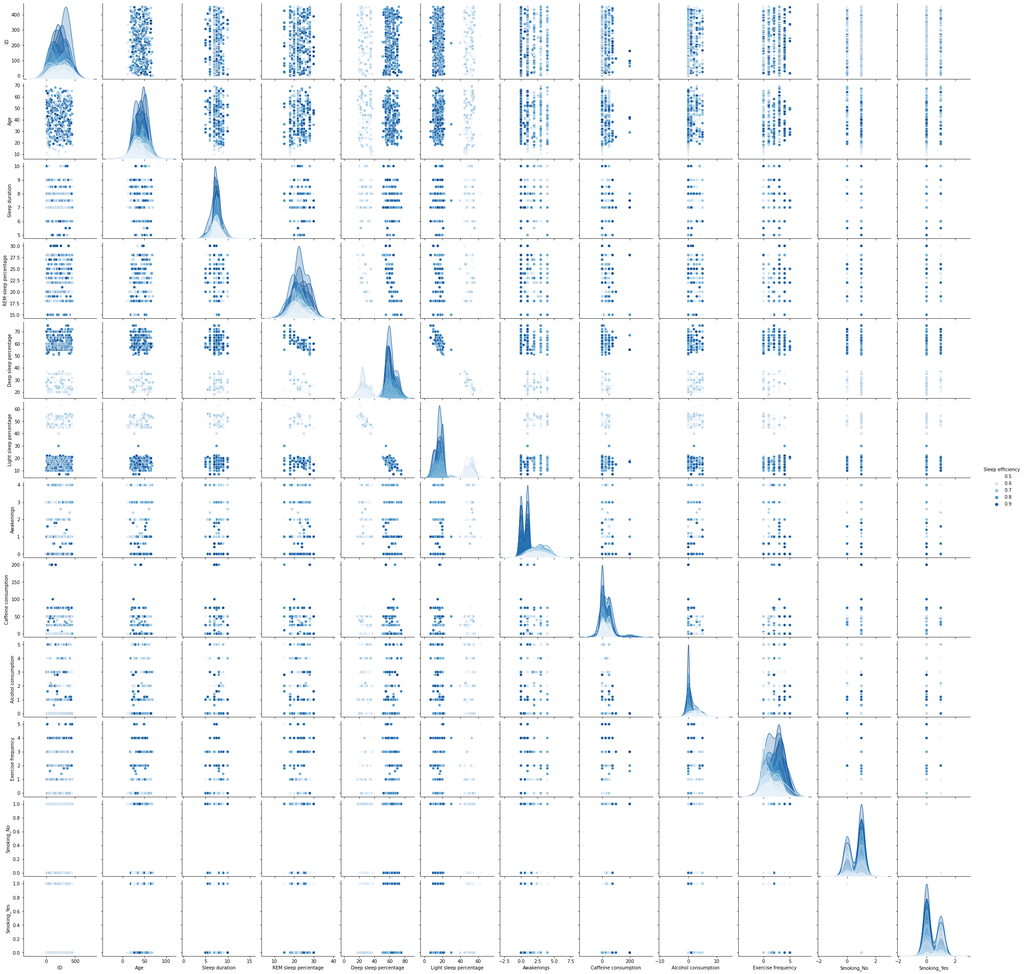

```python
sns.pairplot(df,hue='Sleep efficiency',palette='Blues')
```

```python
# Calculate average deep sleep and light sleep percentages for men and women
gender_avg = df.groupby('Gender')['Deep sleep percentage', 'Light sleep percentage'].mean()

# Calculate average deep sleep and light sleep percentages for smokers and non-smokers
smoking_avg = df.groupby('Smoking_Yes')['Deep sleep percentage', 'Light sleep percentage'].mean()

# Display the results
print("Average deep sleep and light sleep percentages by gender:")
print(gender_avg)

print("\nAverage deep sleep and light sleep percentages by smoking status:")
print(smoking_avg)
```

```
Average deep sleep and light sleep percentages by gender:
        Deep sleep percentage  Light sleep percentage
Gender
Female                 51.625               25.187500
Male                   54.000               23.947368

Average deep sleep and light sleep percentages by smoking status:
             Deep sleep percentage  Light sleep percentage
Smoking_Yes
0                        55.372483               22.093960
1                        47.889610               29.337662
```

The data provided reveals some differences in average deep sleep and light sleep percentages based on gender and smoking status.

In terms of gender, the analysis shows that females had a slightly lower average deep sleep percentage compared to males (51.625% vs. 54.000%). Conversely, females had a slightly higher average light sleep percentage compared to males (25.1875% vs. 23.947368%). These findings suggest that there may be subtle variations in sleep patterns between genders, with males tending to have slightly more deep sleep and females experiencing slightly more light sleep on average.

Regarding smoking status, the data indicates that non-smokers (Smoking_Yes = 0) had a higher average deep sleep percentage compared to smokers (55.372483% vs. 47.88961%). On the other hand, smokers had a higher average light sleep percentage compared to non-smokers (29.337662% vs. 22.09396%). This suggests that smoking may have some influence on sleep patterns, with non-smokers tending to have more deep sleep and smokers exhibiting more light sleep on average. It's important to note that these observations are based on the provided data and further research is needed to establish a more comprehensive understanding of the relationship between smoking and sleep.

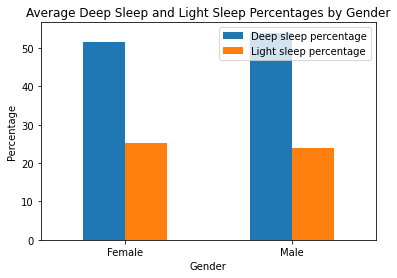

```python
# Plot bar chart for average deep sleep and light sleep percentages by gender
gender_avg.plot(kind='bar', rot=0)
plt.title('Average Deep Sleep and Light Sleep Percentages by Gender')
plt.xlabel('Gender')
plt.ylabel('Percentage')
plt.legend()
plt.show()
```

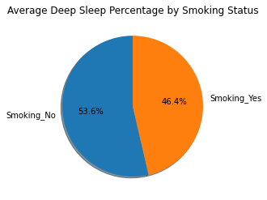

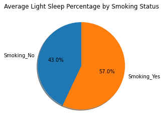

```python
# Plot pie chart for average deep sleep and light sleep percentages by smoking status
fig, ax = plt.subplots()
ax.pie(smoking_deep_sleep, labels=smoking_labels, autopct='%1.1f%%', startangle=90, shadow=True)
ax.set_title('Average Deep Sleep Percentage by Smoking Status')
plt.show()

fig, ax = plt.subplots()
ax.pie(smoking_light_sleep, labels=smoking_labels, autopct='%1.1f%%', startangle=90, shadow=True)
ax.set_title('Average Light Sleep Percentage by Smoking Status')
plt.show()
```

Age distribution

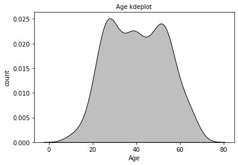

```python
sns.kdeplot(data=df, x="Age",color="black",fill=True)
plt.xlabel("Age", color="black", fontsize=10)
plt.ylabel("count", color="black", fontsize=10)
plt.title("Age kdeplot", color="black",fontsize=10)
plt.show()
```

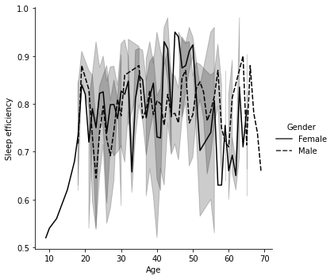

```python
sns.relplot(
    data=df, kind="line",
    x="Age", y="Sleep efficiency", style="Gender", color="black"
)
plt.show()
```

```python
# Let's see if there is imbalance in the data
```

```python
df.Gender.value_counts()
```

```
Male      228
Female    224
Name: Gender, dtype: int64
```

This dataset is well-balanced as it consists of 228 males and 224 females, ensuring a nearly equal representation of both genders.

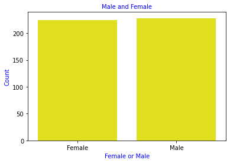

```python
sns.countplot(data=df,x="Gender", color="yellow")
plt.xlabel("Female or Male", color="blue",fontsize=10)
plt.ylabel("Count", color="blue",fontsize=10)
plt.title("Male and Female", color="blue",fontsize=10)
plt.show()
```

# Boxplot for smokers and non smokers

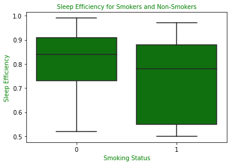

```python
# Adjust the code for the box plot
sns.boxplot(data=df, x="Smoking_Yes", y="Sleep efficiency", color="green")
plt.xlabel("Smoking Status", color="green", fontsize=10)
plt.ylabel("Sleep Efficiency", color="green", fontsize=10)
plt.title("Sleep Efficiency for Smokers and Non-Smokers", color="green", fontsize=10)
plt.show()
```

On average, non-smokers tend to have better sleep efficiency compared to smokers. Additionally, the minimum sleep efficiency observed in smokers is lower than that of non-smokers.